# Ordinal Regression: ING-IN’ across diff Tweeter genders

### What is the data?

From an experiment in which ~300 people saw one ‘Tweet’ each.

- Four conditions in all:
  - Two gender conditions (‘The Tweeter is male/female’)
  - Two (ING) conditions: Tweeter uses either *walkin’* or *walking*

#### Get data and tidy it

(nb, this data has already been tidied up a bunch - eg participants excluded where necessary. This notebook is really just for BRMS tute)

```r
ingin.gender <- read.csv('ing_gender.csv')

#Tidy up (make factors factors, rename cols for transparency)
cols <- 5:17 #cols to be factors
ingin.gender %<>% rename(participant_gender = gender,
                 tweeter_gender = user_gender,
                 participant_education = education,
                 socialmeda_usage = socialmedia,
                 participant_age = age) %>%
                 mutate_at(cols, factor) %>%
                 dplyr::filter(participant_gender != 'Other') #iltering as so few (2) responses

ingin.gender$grammar <- as.factor(ingin.gender$grammar) #oops forgot him
```

*A note on variable names and scales… the ends of the Likert items are pseudorandomized - such that in some cases, 1 represents the highest extent of the attribute, and in others, 7 does. E.g., for masculinity and femininity, most masculine/feminine = 1, least masculine/feminine = 7. The variables are named to reflect this: the first part of the variable name reflects the left side of the scale (1) and the second part, the right side (7).*

### Ordinal regression models with `fem_not` and `masc_not` as response variables

These are the frequentist ordinal regression models using `clm`.

```r
fem.gend.mod <- clm(factor(fem_not) ~ stim*tweeter_gender*participant_gender,  data = ingin.gender)
summary(fem.gend.mod)
```

```
## formula: factor(fem_not) ~ stim * tweeter_gender * participant_gender
## data:    ingin.gender
##
##  link  threshold nobs logLik  AIC    niter max.grad cond.H
##  logit flexible  294  -455.98 937.96 6(0)  1.81e-08 2.8e+02
##
## Coefficients:
##                                                        Estimate Std. Error
## stimnoth_inn                                             0.4133     0.3976
## tweeter_gendermale                                       2.0962     0.4154
## participant_genderMale                                   0.5911     0.4530
## stimnoth_inn:tweeter_gendermale                         -0.2597     0.5854
## stimnoth_inn:participant_genderMale                      0.2530     0.6542
## tweeter_gendermale:participant_genderMale               -1.7108     0.6267
## stimnoth_inn:tweeter_gendermale:participant_genderMale   0.7148     0.8801
##                                                        z value Pr(>|z|)
## stimnoth_inn                                             1.039  0.29860
## tweeter_gendermale                                       5.046 4.51e-07
## participant_genderMale                                   1.305  0.19190
## stimnoth_inn:tweeter_gendermale                         -0.444  0.65727
## stimnoth_inn:participant_genderMale                      0.387  0.69896
## tweeter_gendermale:participant_genderMale               -2.730  0.00634
## stimnoth_inn:tweeter_gendermale:participant_genderMale   0.812  0.41669
##
## stimnoth_inn
## tweeter_gendermale                                     ***
## participant_genderMale
## stimnoth_inn:tweeter_gendermale
## stimnoth_inn:participant_genderMale
## tweeter_gendermale:participant_genderMale              **
## stimnoth_inn:tweeter_gendermale:participant_genderMale
## ---
## Signif. codes:  0 '***' 0.001 '**' 0.01 '*' 0.05 '.' 0.1 ' ' 1
##
## Threshold coefficients:
##     Estimate Std. Error z value
## 1|2  -1.9714     0.3263  -6.042
## 2|3  -0.9729     0.2706  -3.596
## 3|4   0.1169     0.2541   0.460
## 4|5   2.2571     0.2901   7.781
## 5|6   3.2312     0.3173  10.183
## 6|7   4.4646     0.3879  11.510
```

```r
masc.gend.mod <- clm(masc_not ~ stim*tweeter_gender*participant_gender,  data = ingin.gender)
summary(masc.gend.mod)
```

```
## formula: masc_not ~ stim * tweeter_gender * participant_gender
## data:    ingin.gender
##
##  link  threshold nobs logLik  AIC    niter max.grad cond.H
##  logit flexible  294  -425.95 877.90 7(0)  3.14e-14 2.6e+02
##
## Coefficients:
##                                                        Estimate Std. Error
## stimnoth_inn                                             0.1166     0.3825
## tweeter_gendermale                                      -1.2530     0.4164
## participant_genderMale                                  -0.5489     0.4575
## stimnoth_inn:tweeter_gendermale                         -1.1266     0.5932
## stimnoth_inn:participant_genderMale                     -0.2454     0.6536
## tweeter_gendermale:participant_genderMale                1.1146     0.6344
## stimnoth_inn:tweeter_gendermale:participant_genderMale  -0.3584     0.8944
##                                                        z value Pr(>|z|)
## stimnoth_inn                                             0.305  0.76060
## tweeter_gendermale                                      -3.009  0.00262 **
## participant_genderMale                                  -1.200  0.23022
## stimnoth_inn:tweeter_gendermale                         -1.899  0.05754 .
## stimnoth_inn:participant_genderMale                     -0.376  0.70728
## tweeter_gendermale:participant_genderMale                1.757  0.07895 .
## stimnoth_inn:tweeter_gendermale:participant_genderMale  -0.401  0.68866
## ---
## Signif. codes:  0 '***' 0.001 '**' 0.01 '*' 0.05 '.' 0.1 ' ' 1
##
## Threshold coefficients:
##     Estimate Std. Error z value
## 1|2 -5.02047    0.47611 -10.545
## 2|3 -3.72813    0.35324 -10.554
## 3|4 -2.50153    0.30246  -8.271
## 4|5 -0.02308    0.25432  -0.091
## 5|6  1.07014    0.27058   3.955
## 6|7  2.17309    0.32754   6.635
```

Unsurpisingly: if particpants are told the Tweeter is a male, then they are considered much less feminine than if participants are told the Tweeter is a female (duh), and vice versa (duh).

More suprising is in the interaction between participant gender and tweeter gender for femininity (marginal interaction for masculinity). See plot below (but be wary as I’m plotting means which technically I shouldn’t really be doing).

### viz this

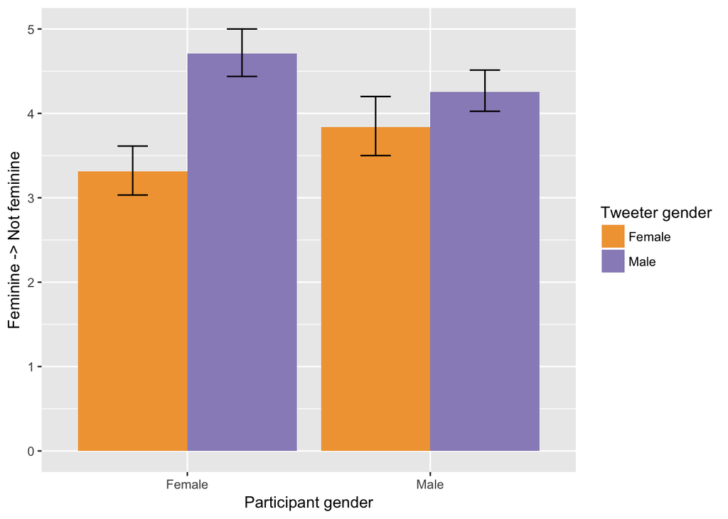

### Ordinal regression with brms

```r
  # BRMS expects ordinal scales to be coded as integers
  ingin.gender$fem_not_int = as.integer(ingin.gender$fem_not)

  # estimate Bayesian ordinal regression model
  fem.gend.bmod <- brm(
    formula =fem_not_int ~ stim*tweeter_gender*participant_gender,
    data = ingin.gender,
    family = cumulative("probit") # proper distribution for likert scales
  )
```

[output not shown]

[output cut: 61 more lines]

[output not shown]

```r
  # run model checks
  check_all_diagnostics(fem.gend.bmod$fit)
```

```
## [1] "n_eff / iter looks reasonable for all parameters"
## [1] "Rhat looks reasonable for all parameters"
## [1] "0 of 4000 iterations ended with a divergence (0%)"
## [1] "0 of 4000 iterations saturated the maximum tree depth of 10 (0%)"
## [1] "E-FMI indicated no pathological behavior"
```

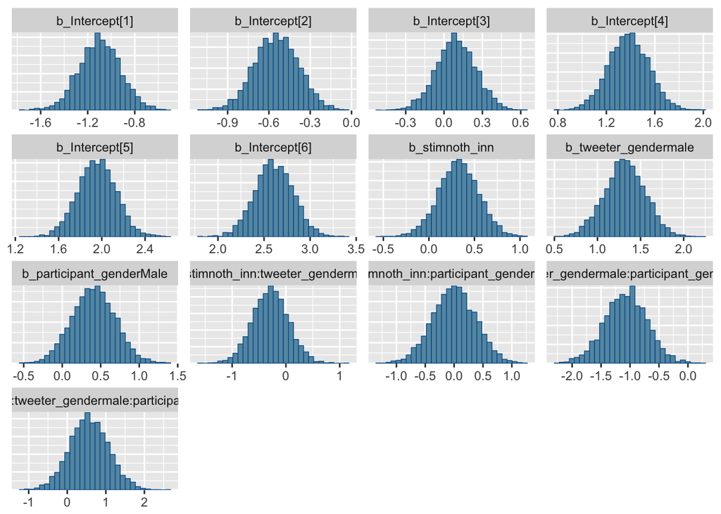

```r
  # plot parameter distributions
  stanplot(fem.gend.bmod, type="hist")
```

```r
  # posterior predictive check
  pp_check(fem.gend.bmod, nsamples=100, type="bars")
```

[figure not shown]

```r
  #display summary
  summary(fem.gend.bmod)
```

```
##  Family: cumulative
##   Links: mu = probit; disc = identity
## Formula: fem_not_int ~ stim * tweeter_gender * participant_gender
##    Data: ingin.gender (Number of observations: 294)
## Samples: 4 chains, each with iter = 2000; warmup = 1000; thin = 1;
##          total post-warmup samples = 4000
##
## Population-Level Effects:
##                                                        Estimate Est.Error
## Intercept[1]                                              -1.10      0.18
## Intercept[2]                                              -0.54      0.16
## Intercept[3]                                               0.09      0.15
## Intercept[4]                                               1.38      0.17
## Intercept[5]                                               1.95      0.18
## Intercept[6]                                               2.61      0.21
## stimnoth_inn                                               0.33      0.22
## tweeter_gendermale                                         1.32      0.24
## participant_genderMale                                     0.41      0.28
## stimnoth_inn:tweeter_gendermale                           -0.28      0.33
## stimnoth_inn:participant_genderMale                       -0.00      0.37
## tweeter_gendermale:participant_genderMale                 -1.07      0.37
## stimnoth_inn:tweeter_gendermale:participant_genderMale     0.57      0.50
##                                                        l-95% CI u-95% CI
## Intercept[1]                                              -1.44    -0.75
## Intercept[2]                                              -0.86    -0.24
## Intercept[3]                                              -0.21     0.39
## Intercept[4]                                               1.05     1.71
## Intercept[5]                                               1.60     2.30
## Intercept[6]                                               2.20     3.02
## stimnoth_inn                                              -0.11     0.76
## tweeter_gendermale                                         0.85     1.78
## participant_genderMale                                    -0.13     0.96
## stimnoth_inn:tweeter_gendermale                           -0.94     0.36
## stimnoth_inn:participant_genderMale                       -0.73     0.73
## tweeter_gendermale:participant_genderMale                 -1.82    -0.36
## stimnoth_inn:tweeter_gendermale:participant_genderMale    -0.40     1.59
##                                                        Eff.Sample Rhat
## Intercept[1]                                                 2849 1.00
## Intercept[2]                                                 2826 1.00
## Intercept[3]                                                 2763 1.00
## Intercept[4]                                                 2507 1.00
## Intercept[5]                                                 2697 1.00
## Intercept[6]                                                 2980 1.00
## stimnoth_inn                                                 2081 1.00
## tweeter_gendermale                                           2078 1.00
## participant_genderMale                                       1717 1.00
## stimnoth_inn:tweeter_gendermale                              1932 1.00
## stimnoth_inn:participant_genderMale                          1697 1.00
## tweeter_gendermale:participant_genderMale                    1519 1.00
## stimnoth_inn:tweeter_gendermale:participant_genderMale       1463 1.00
##
## Samples were drawn using sampling(NUTS). For each parameter, Eff.Sample
## is a crude measure of effective sample size, and Rhat is the potential
## scale reduction factor on split chains (at convergence, Rhat = 1).
```

```r
  ## repeat all steps for model predicting "masc_not"
  ingin.gender$masc_not_int = as.integer(ingin.gender$masc_not)

  masc.gend.bmod <- brm(
    formula =masc_not_int ~ stim*tweeter_gender*participant_gender,
    data = ingin.gender,
    family = cumulative("probit")
  )
```

```
## recompiling to avoid crashing R session
```

[output not shown]

[output cut: 52 more lines]

[output not shown]

```r
  check_all_diagnostics(masc.gend.bmod$fit)
```

```
## [1] "n_eff / iter looks reasonable for all parameters"
## [1] "Rhat looks reasonable for all parameters"
## [1] "0 of 4000 iterations ended with a divergence (0%)"
## [1] "0 of 4000 iterations saturated the maximum tree depth of 10 (0%)"
## [1] "E-FMI indicated no pathological behavior"
```

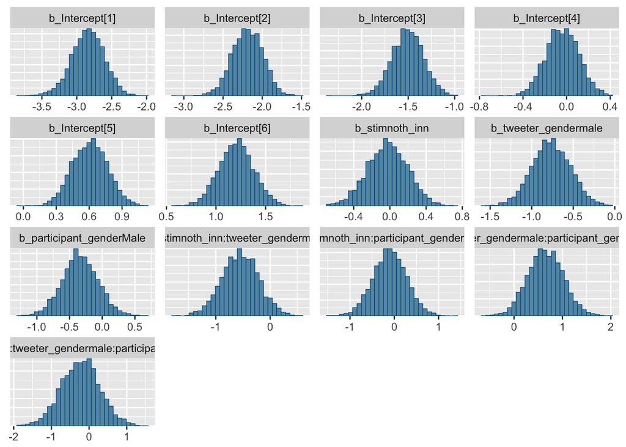

```r
  stanplot(masc.gend.bmod, type="hist")
```

```r
  pp_check(masc.gend.bmod, nsamples=100, type="bars")
```

[figure not shown]

```r
  summary(masc.gend.bmod)
```

```
##  Family: cumulative
##   Links: mu = probit; disc = identity
## Formula: masc_not_int ~ stim * tweeter_gender * participant_gender
##    Data: ingin.gender (Number of observations: 294)
## Samples: 4 chains, each with iter = 2000; warmup = 1000; thin = 1;
##          total post-warmup samples = 4000
##
## Population-Level Effects:
##                                                        Estimate Est.Error
## Intercept[1]                                              -2.84      0.23
## Intercept[2]                                              -2.19      0.19
## Intercept[3]                                              -1.51      0.17
## Intercept[4]                                              -0.04      0.15
## Intercept[5]                                               0.61      0.16
## Intercept[6]                                               1.20      0.18
## stimnoth_inn                                              -0.03      0.22
## tweeter_gendermale                                        -0.77      0.23
## participant_genderMale                                    -0.34      0.27
## stimnoth_inn:tweeter_gendermale                           -0.55      0.34
## stimnoth_inn:participant_genderMale                       -0.10      0.38
## tweeter_gendermale:participant_genderMale                  0.65      0.37
## stimnoth_inn:tweeter_gendermale:participant_genderMale    -0.22      0.51
##                                                        l-95% CI u-95% CI
## Intercept[1]                                              -3.32    -2.40
## Intercept[2]                                              -2.57    -1.83
## Intercept[3]                                              -1.85    -1.18
## Intercept[4]                                              -0.33     0.26
## Intercept[5]                                               0.30     0.92
## Intercept[6]                                               0.86     1.55
## stimnoth_inn                                              -0.46     0.40
## tweeter_gendermale                                        -1.22    -0.32
## participant_genderMale                                    -0.87     0.21
## stimnoth_inn:tweeter_gendermale                           -1.21     0.11
## stimnoth_inn:participant_genderMale                       -0.84     0.64
## tweeter_gendermale:participant_genderMale                 -0.05     1.37
## stimnoth_inn:tweeter_gendermale:participant_genderMale    -1.22     0.78
##                                                        Eff.Sample Rhat
## Intercept[1]                                                 2763 1.00
## Intercept[2]                                                 3299 1.00
## Intercept[3]                                                 2798 1.00
## Intercept[4]                                                 2593 1.00
## Intercept[5]                                                 2780 1.00
## Intercept[6]                                                 2849 1.00
## stimnoth_inn                                                 2530 1.00
## tweeter_gendermale                                           2342 1.00
## participant_genderMale                                       2274 1.00
## stimnoth_inn:tweeter_gendermale                              2274 1.00
## stimnoth_inn:participant_genderMale                          2214 1.00
## tweeter_gendermale:participant_genderMale                    2138 1.00
## stimnoth_inn:tweeter_gendermale:participant_genderMale       2081 1.00
##
## Samples were drawn using sampling(NUTS). For each parameter, Eff.Sample
## is a crude measure of effective sample size, and Rhat is the potential
## scale reduction factor on split chains (at convergence, Rhat = 1).
```